# RED WINES EXPLORATION by Anna Antonova

### Chlorides

Chlorides are salts and in larger amounts will give a wine salty taste. At some levels it probably goes unnoticed. Chlorides can also compensate for too high acidity. Later I will explore the combination of chlorides and acidity and its influence on wine quality.

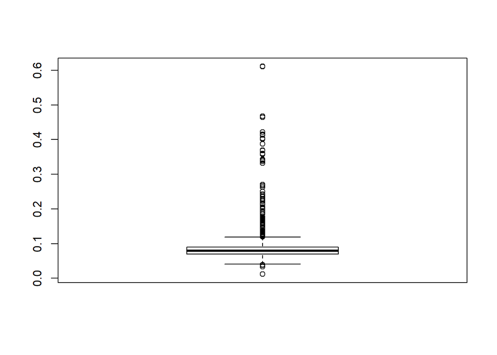

There are a lot of outliers. I will draw a boxplot for chlorides < 0.12 g/l

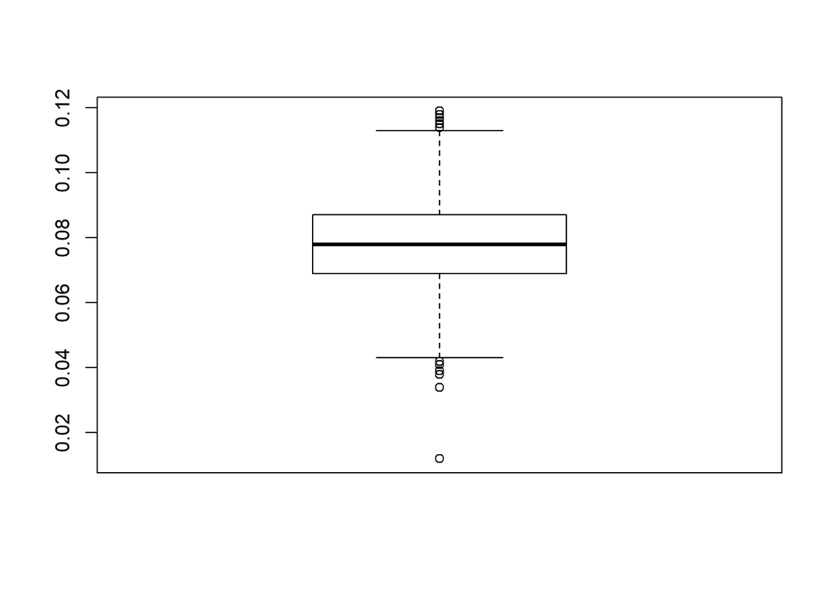

50% of observations of chlorides content are below 0.08 g/l. The distribution has a small spread: lower quartile is at 0.07 and upper quartile is at 0.09 g/l. I wonder how many outliers are there?

```
##  75%
## 0.12
```

```
##  25%
## 0.04
```

Lower outlier limit is 0.04 g/l and upper outlier limit is 0.12 g/l

```
## [1] 100
```

```
## [1] 9
```

There are 100 upper outliers: wines with pretty high chlorides content. There are only 9 lower outlier. I wonder how total acidity is distributed among these wines?

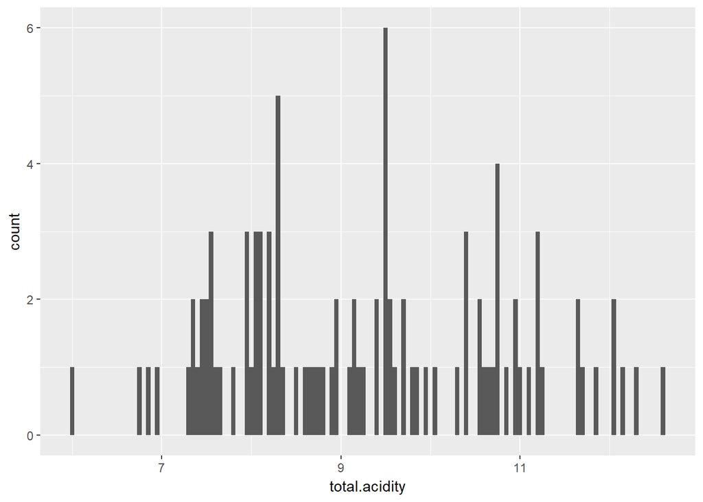

Compared to total acidity distribution of all wines this distribution is shifted to the right, the median is around 9., whereas the median of all wines acidity was at around 7.75. Is higher chlorides content related to higher acidity?

I would like to check if there are NA values in the dataset.

```
##                  wine.id            fixed.acidity         volatile.acidity
##                        0                        0                        0
##              citric.acid           residual.sugar                chlorides
##                        0                        0                        0
##      free.sulfur.dioxide     total.sulfur.dioxide                  density
##                        0                        0                        0
##                       pH                sulphates                  alcohol
##                        0                        0                        0
##                  quality           quality_factor          quality_grouped
##                        0                        0                        0
##    fixed.acidity_grouped volatile.acidity_grouped            total.acidity
##                        0                        0                        0
##          alcohol_grouped
##                        0
```

Now, I would like to create a new data frame named “grouped_data”. I will group wines by alcohol content group and volatile acidity group and quality. I will then calculate median value for each predictor variable and each combination of alcohol group, volatile acidity group and quality. I will transform this data frame by gathering all predictor variables columns as values in a new column “predictor”

```
##          alcohol_grouped              volatile.acidity_grouped
##  Very low alcohol:104    very low volatile acidity: 65
##  Low alcohol     :195    low volatile acidity     :208
##  Average alcohol :234    average volatile acidity :247
##  High alcohol    :182    high volatile acidity    :195
##
##
##
##     quality      quality_factor            predictor       median
##  Min.   :3.000   3: 52          alcohol         : 55   Min.   :  0.010
##  1st Qu.:5.000   4:104          volatile.acidity: 55   1st Qu.:  0.635
##  Median :6.000   5:182          fixed.acidity   : 55   Median :  3.250
##  Mean   :5.618   6:182          total.acidity   : 55   Mean   :  9.200
##  3rd Qu.:7.000   7:117          citric.acid     : 55   3rd Qu.:  9.500
##  Max.   :8.000   8: 78          pH              : 55   Max.   :373.000
##                                 (Other)         :385
```

# Univariate Analysis

### What is the structure of your dataset?

There are 1599 observations in the data set with 12 features, the 13th variable is numerical ID of each wine. The features are physicochemical properties (independent variables): acidity: volatile, fixed and citric, pH, residual sugars, alcohol, sulfur dioxide: free and total, sulphates, chlorides, density. The dependent variable is quality on the scale of 0 to 10. All variables are numeric, float type, except for quality which is numeric integer. Sulfur dioxode is measured in mg/l, density in g/dl, alcohol in %, other physicochemical properties in g/l. Quality is going from 0 to 10, from worst to best quality, 10 being the best wine.

Other observations:

1. Most wines are of average quality with grades of 5 or 6
2. Median quality grade is 6.
3. The worst grade for this sample is 3 and the best is 8.
4. Low (grades 3 or 4) and high (grade 8) quality wines represent only 5% of observations.
5. There are no missing values in the data set.
6. The only 0 values present in the data set are for citric acid content.
7. Most wines have total acidity of around 8 g/l.
8. There are a lot of outliers in fixed and volatile acidity observtions, as well as in residual sugar observations.
9. Most of wines have total acidity at around 8 g/l, residual sugar at 2 g/l, free sulfur dioxide at around 6 mg/l, alcohol content at around 9.25%.

### What is/are the main feature(s) of interest in your dataset?

My first impression is that acidity and alcohol play an important role in general taste.

### What other features in the dataset do you think will help support your investigation into your feature(s) of interest?

Chlorides and free sulfur dioxide might at certain levels affect the taste. Citric acid content seems to enhance the wine’s taste. But the balance of different parameters is essential.

### Did you create any new variables from existing variables in the dataset?

Yes. I converted the variable “quality” into a factor and added this new variable to the data set. I also created a new variable “total acidity” adding “volatile” and “fixed” acidity. It is difficult to tell apart different types of acidity (except for citric acid), what we taste is total acidity. That is why I might explore the influence of total acidity on the general taste. I created categorical variabes by grouping wines by alcohol content, volatile acidity and fixed acidity. I would like to explore data by different groups.

### Of the features you investigated, were there any unusual distributions? Did you perform any operations on the data to tidy, adjust, or change the form of the data? If so, why did you do this?

I decided to organize data in a new data frame grouping them by alcohol content, volatile acidity and quality and calculating median value for each variable. I then gathered the data to use variables names as values in column “predictor”. I plan using this data frame for plots in multivariate section.

# Bivariate Plots Section

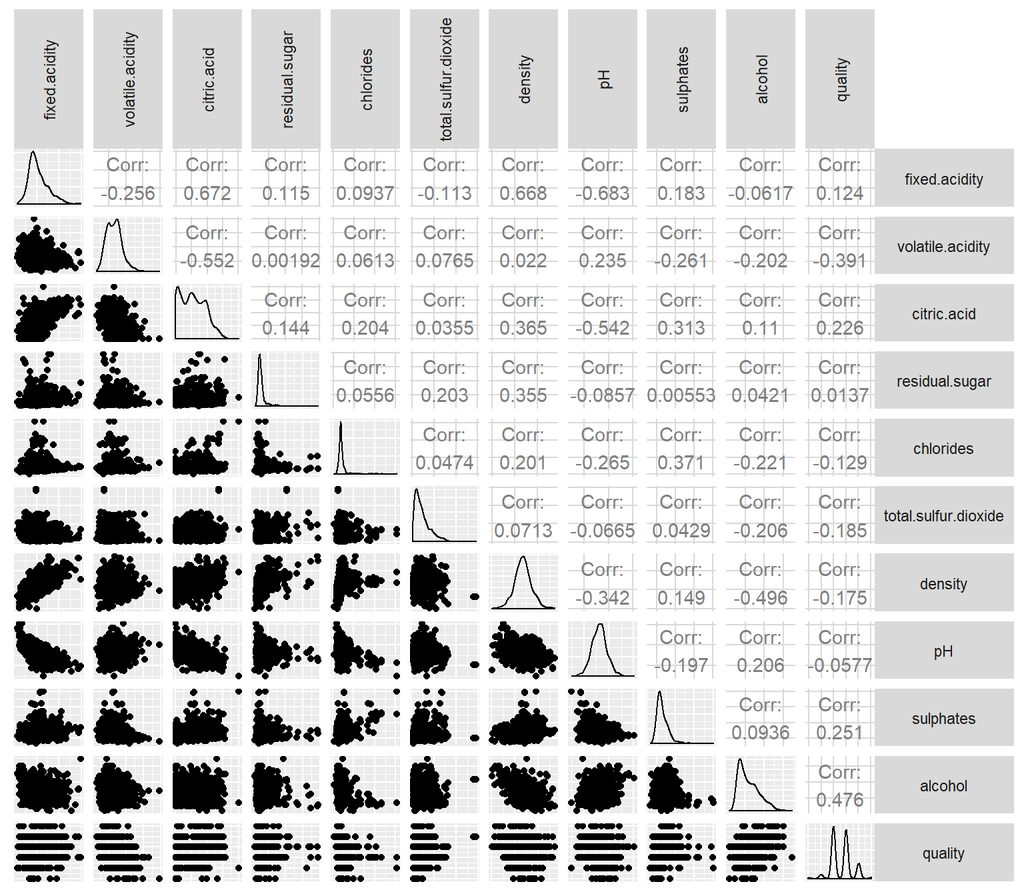

I excluded free.sulfur dioxide from the table as the correlation cofficient is very low. Here it is:

```
## [1] -0.05065606
```

Let’s start with relationship between alcohol and quality.

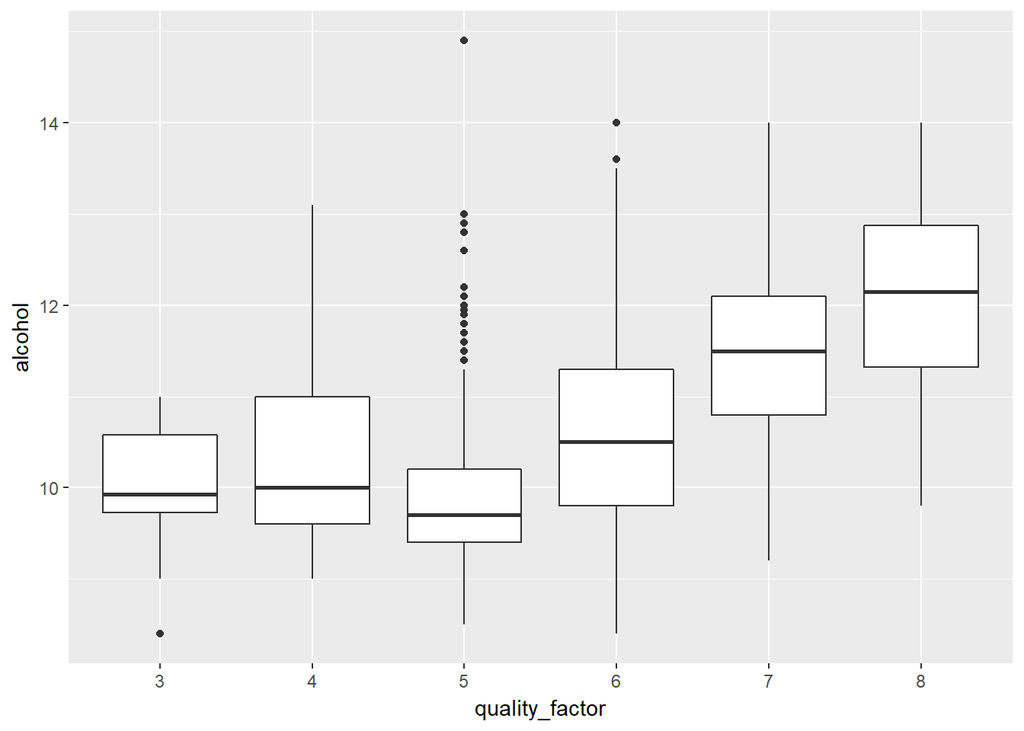

From this plot we see that median alcohol content per quality grade is generally increasing with grade. Only grade 5 wines have their median lower than grade 3 and 4 wines. These wines have also most upper outliers.

Let’s represent these data in a different way.

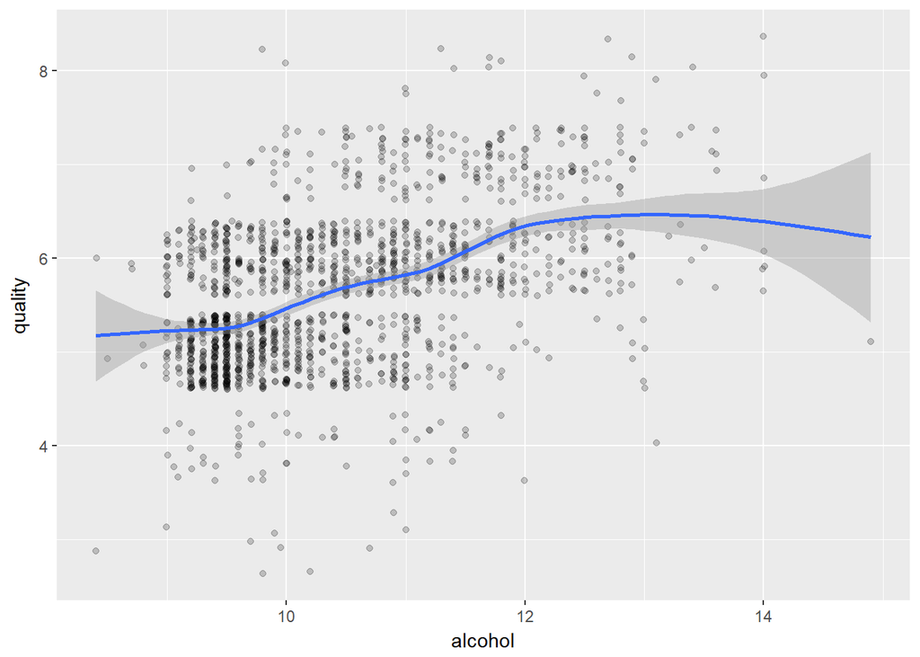

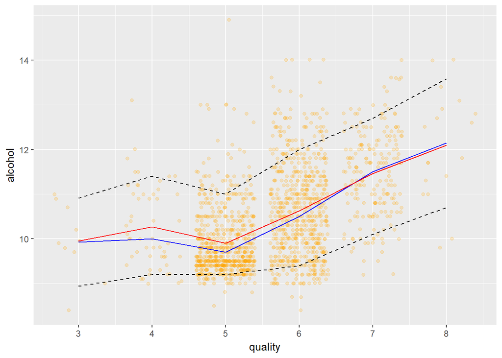

```
##
## Calls:
## m1: lm(formula = quality ~ alcohol, data = redwines)
##
## ================================
##   (Intercept)         1.875***
##                      (0.175)
##   alcohol             0.361***
##                      (0.017)
## --------------------------------
##   R-squared           0.227
##   adj. R-squared      0.226
##   sigma               0.710
##   F                 468.267
##   p                   0.000
##   Log-likelihood  -1721.057
##   Deviance          805.870
##   AIC              3448.114
##   BIC              3464.245
##   N                1599
## ================================
```

Here I tried to create a model with only one predictor: alcohol content. The model explaines about 22.7% on the data.

Next variable with a meningful correlation: volatile acidity.

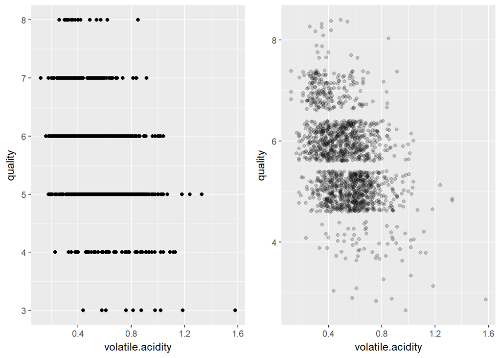

On the left plot we see horizontal lines (as grades are integers) and we can notice a shift in data set from higher grade to lower grade. On the right plot I added noise and some transparency. We can see the descending tendency. Most of observations are in the middle (grade 5 and 6: no surprise here). The lower the grade the more on the right are our observations.

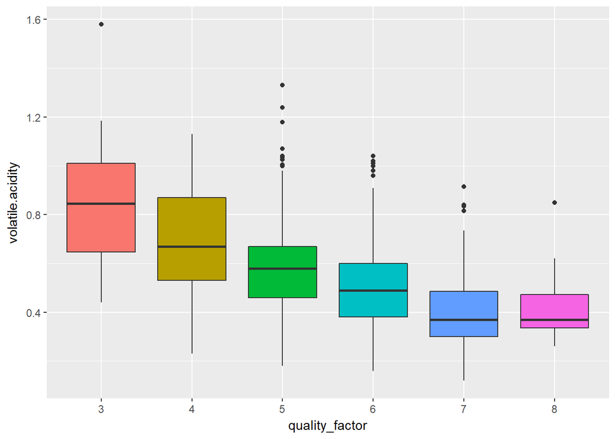

Here I decided to use factor variable quality_factor to represent how observations are distributed for each grade. It confirms our initial assumption that there is a negative relationship between volatile acidity and quality. The higher is the grade the lower is its median, as well as whiskers ends. Except for medians for 7 and 8 grade - they are the same.

Only exception: lower whiskey end of 8 grade wines is higher than 7 grade wines. May be this is simply due to unsufficient number of observations.

Another observation: there are only upper outliers and grades 5 and 6 have most of them. The higher the grade the smaller is volatile acidity spread for the central 50% of data.

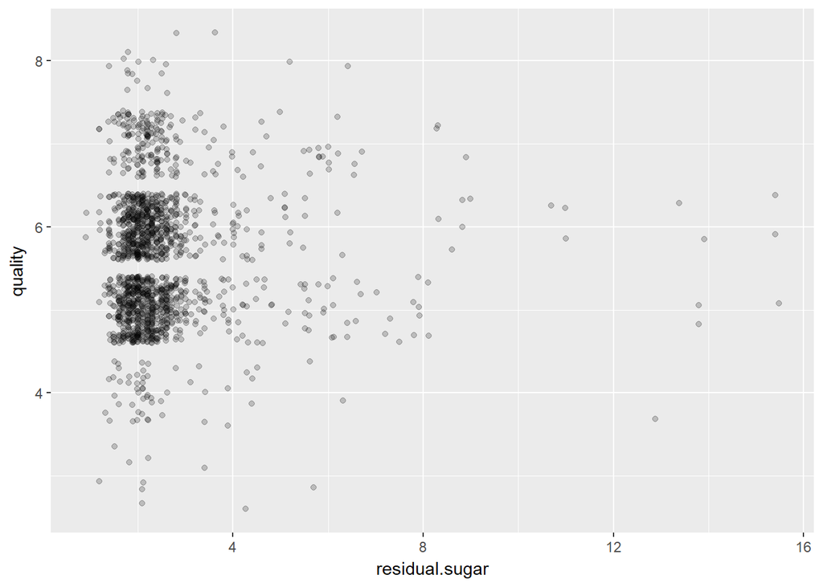

The dsitribution of data points seems similar for best and worst wines (graded 3 and 8). There are more observations and a bigger spread for average quality wines. This is certainly related to the number of observations. Here we see that there is no relationship between residual sugar and quality despite what I assumed in Univariate analysis section. This is also confirmed by the correlation coefficient of only 0.0137. I notice though that most grade 3, 4 and 8 wines do not have high residual sugar above 6 g/l.

### Quality and sulphates

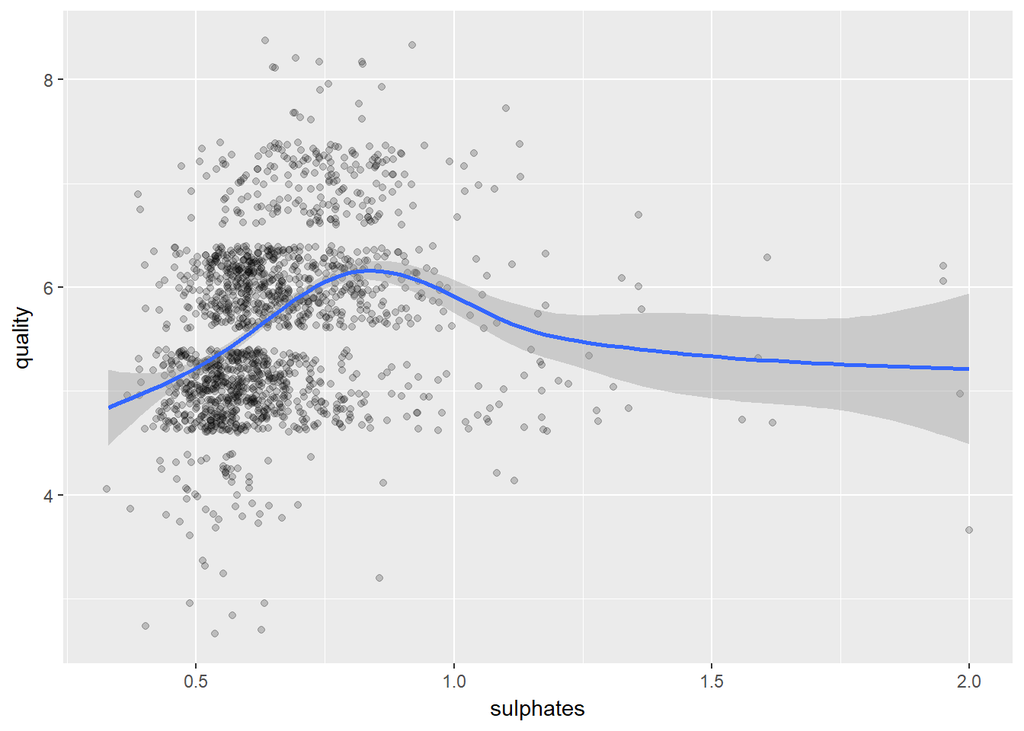

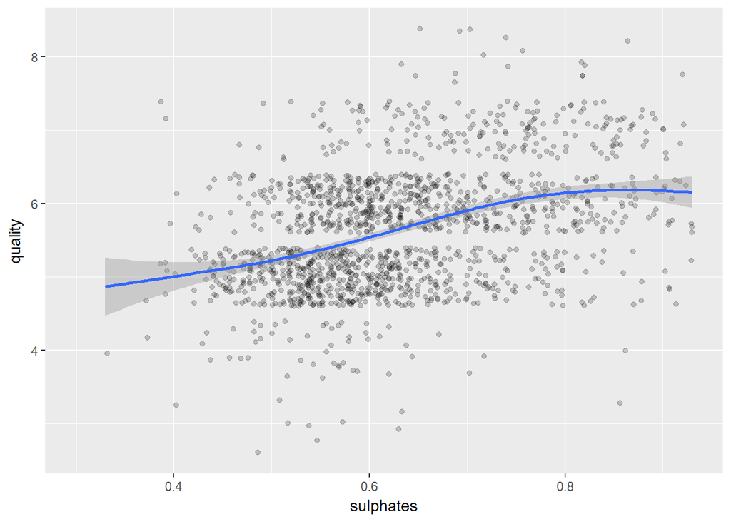

There is a positive relationship between sulphates content and wine quality. On the upper graph I showed all the data whereas on the lower graph I removed the top 5% of observations. On the second graph we can see an ascending tendency. On the first graph we also observe a descendning or flat pattern starting at around 0.9 g/l f sulphates. We need more data to confirm this descending pattern starting at cerain level of sulphates, but it seems possible as with any ingredients of taste too much of any ingredient will hurt the general perception.

### Citric acid and quality

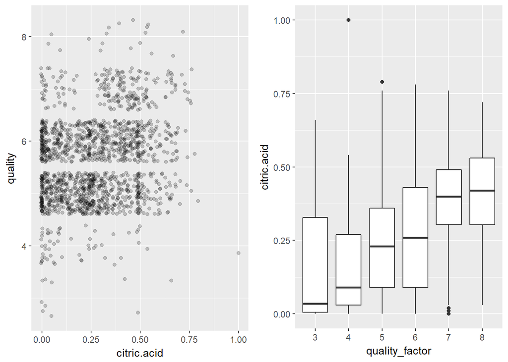

I wanted to check again the fixed acidity even though the correlation coefficient is very small. I still coud not believe that acidity does not affect taste.

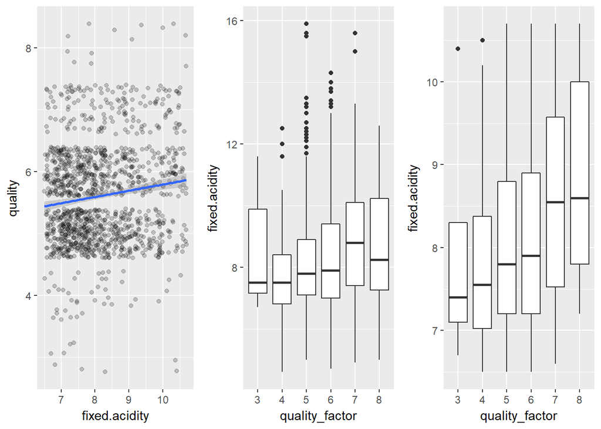

But here we see that there is an ascending trend when we consider only 80% middle observations (the right plot), eliminating lower and top 10%. Is it possible that a combination of fixed acidity and another property (for example, residual sugar or alcohol) influences the taste? I will verify this in Multivariate analysis section.

### Relationship between input variables

### Density and fixed acidity

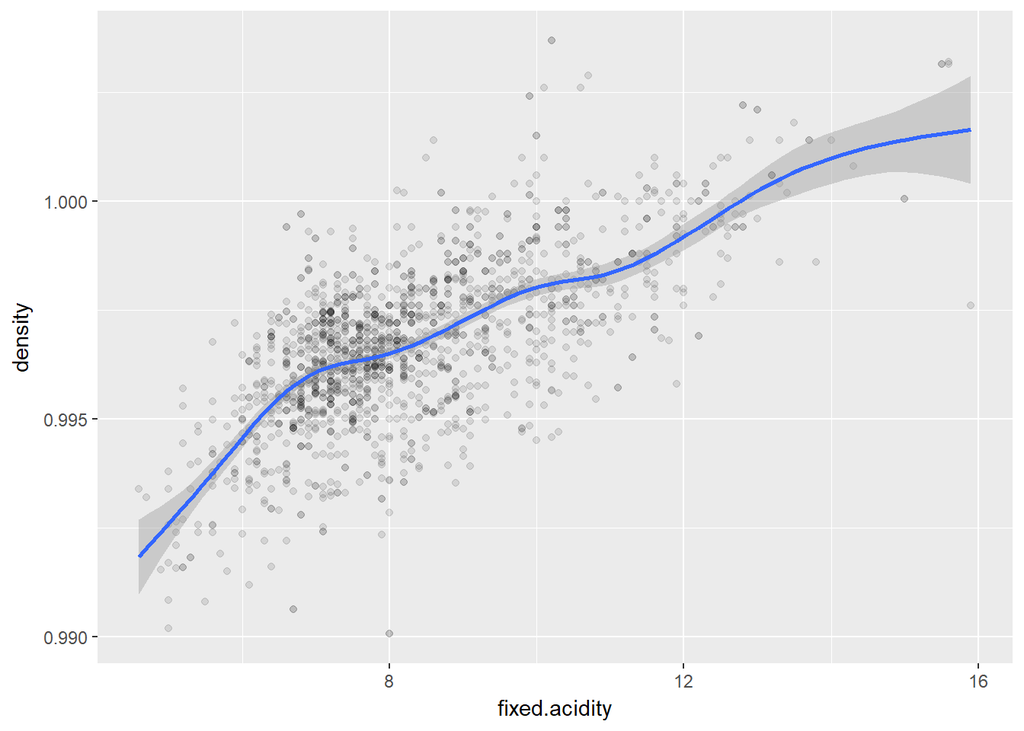

Here we see an ascending trend. The higher the fixed acidity, the higher the density. This is related to the higher density of acids dissolved in water compare to the rest of the liquid in wine. The correlation coefficient is moderate: 0.668.

In general, we notice that density has meaningful correlation with several other variables: alcohol (descending: -0.4962), citric acid (ascending: 0.365), residual sugar (ascending: 0.355), and pH (descending: -0.3425).

### Fixed acidity and pH

A few words about two different measures of acidity: pH is a measure of the acid strength. It is based on logarithmical scale. As an example, pH of 3 means 10 times stronger acidity than pH of 4. Fixed acidity measures different acids content in g per liter. Each particular acid has its own pH, but we don’t know how much of each acid we have in our fixed acidity measure.

So, the pH is cerainly negatively related to fixed acidity, but it is not a clear linear relationship. pH can be the same or even lower for a higher fixed acidity, but the higher the increase in fixed acidity the higher will be the decrease in pH.

Let’s see on a graph:

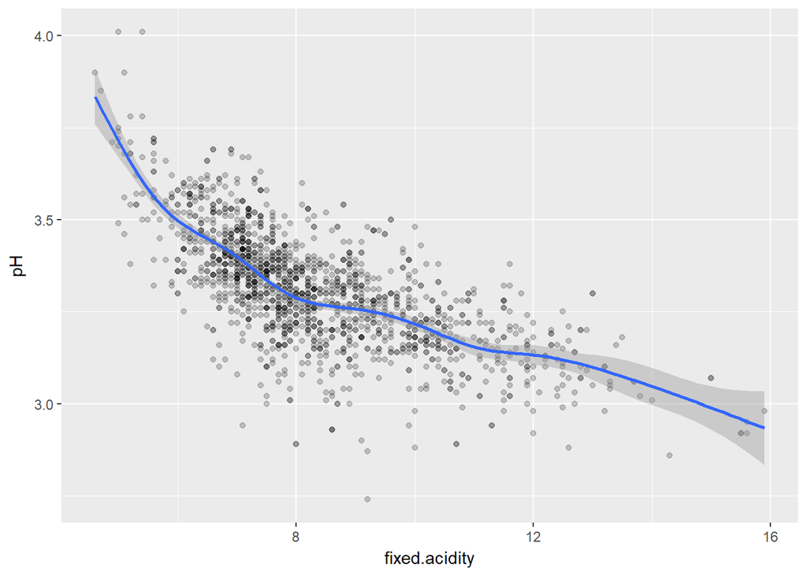

Here the relationship is of a negatively powered function. No surprise - taking into account the definition of pH.

### Citric acid and volatile acidity

Whereas positive relationship between citric acid and fixed acidity is not surprising (correlation coeff: 0.672) - citric acid is one of fixed acids - negative relationship between citric and volatile acids is not that evident. Correlation corefficient is moderately high though: -0.552

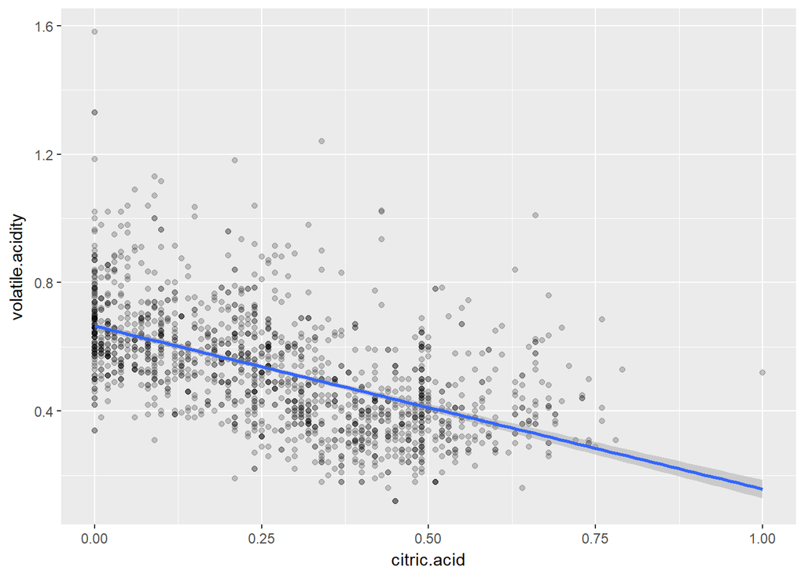

Here the descending trend is clear. The more the citric acid content the lower the volatile acidity. I wonder if this explains the influence of citric acid on quality. May be, it is not citric acid itself that influences wine quality, but a lower volatile acidity that is somehow explained by higher citric acid content. In that case, I should not include citric acid in my model as then, there will be a relationship between two input variables.

# Bivariate Analysis

### Talk about some of the relationships you observed in this part of the investigation. How did the feature(s) of interest vary with other features in the dataset?

1. I explored the relationship between the dependent variable: wine quality or grade and several input variables describing wine physcochemical properties. Based on my exploration, I see that alcohol influences the most the wine quality. The relationship is positive: for most of observations, higher alcohol content corresponds to a higher quality.
2. Second comes volatile acidity that is negatively related to wine quality. The most common among volatile acids in wine is acetic acid the one present in vinegar. The higher the volatile acidity the lower the wine quality as it will give the wine a vinegar taste.
3. Sulphates - surprisingly, and citric acid - as expected, have some positive influence on wine quality (at least, for our sample). Although, the correlation coefficient is not meaningful (0.251 for sulphates and 0.226 for citric acid). I based my conclusion on a slight positive trend on sulphates/quality scatterplot, as well as on citric acid boxplots per grade: medians are clearily increasing as the grade increases.

### Did you observe any interesting relationships between the other features (not the main feature(s) of interest)?

1. Density is related to several variables, which is not surprising as density of certain chemicals might be typically higher or lower than others chemicals. For example if we would explore the relationship between density and quality we would find a correlation, but the real reason for that is that alcohol density is typically lower than other chemicals dissolved in wine and that is alcohol that explains wine quality.
2. Fixed acidity and pH relationship is worth to be mentioned. Those are two different measures of acidity that are negatively related and do not have a linear relationship. I will be interested in fixed acidity rather than pH. This is confirmed by very low correlation coefficient of pH and quality: -0.0577. Also a very low correlaation coefficient between total acidity and quality. So, I won’t consider total acidity as predictor.
3. One important conlusion though is that citric acid and volatile acidity are negatively related. As citric acid itself does not have a meaningful correlation coefficient with wine quality, while volatile acidity does, I should probaby eliminate citric acid from my input variables and keep only volatile acidity.

### What was the strongest relationship you found?

> The strongest relationship is between alcohol content and quality. Although, as high volatile acidity can significantly reduce wine’s grade it will be interesting to explore the three variables together in the next section.

# Multivariate Plots Section

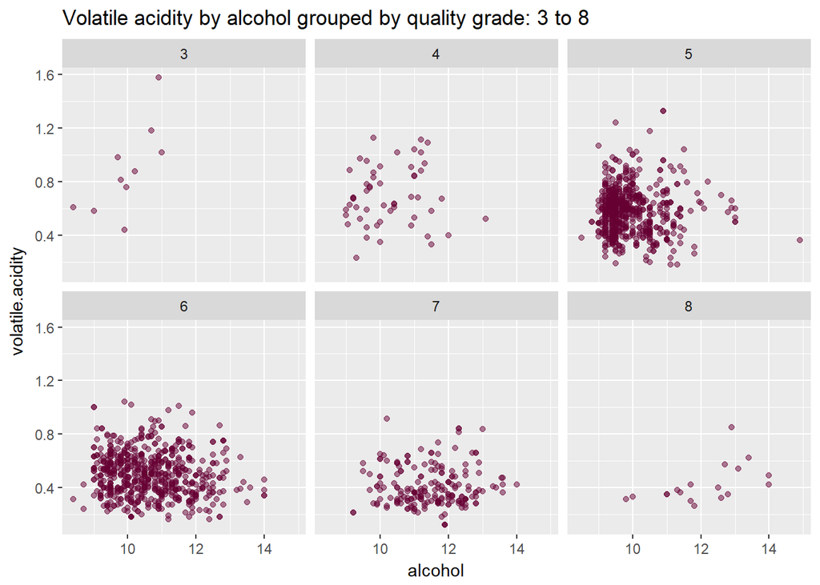

On this plot we see how the combination of alcohol and volatile acidity is realted to wine quality. As wine grade increases the variance of alcohol content increases and volatile acidity variance decreases.

For grade 3 wines volatile acidity varies betweeen 0.4 and 1.6 but alcohol content varies only between 8 and 11%, whereas for grade 8 wines volatile acidity varies between 0.2 and 0.8 and alcohol content varies between 10 and 14%.

Also, most of 5 grade wines have alcohol content between 9 and 10.5%, whereas 6 grade wines - between 9 and 12%.

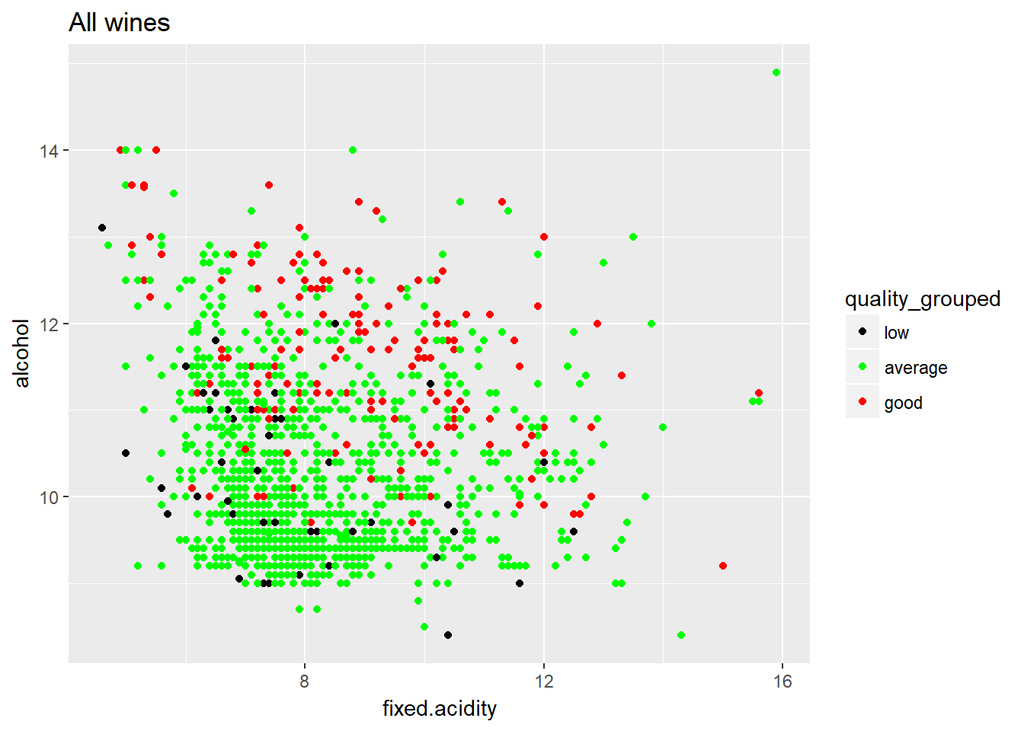

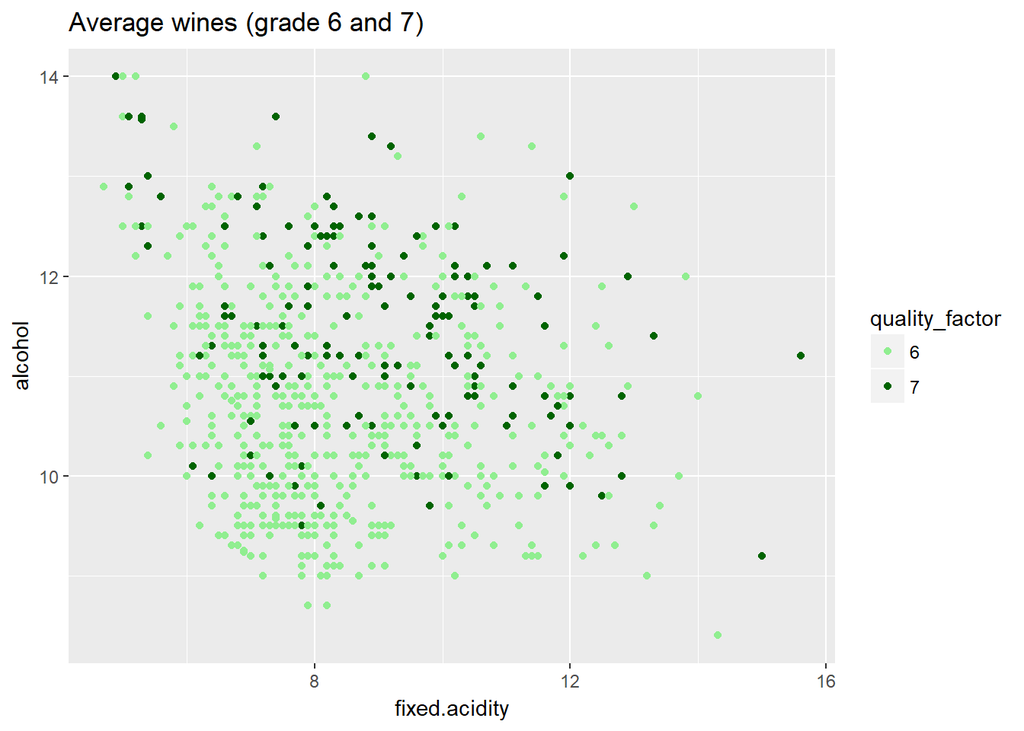

On the upper plot I represented all wines, colored by their grouped quality: low, average and good.

On both graphs we see that points are positioned along a diagonal, better wines being on the upper right side and worse wines being on the lower left side. This shows that if fixed acidity is high enough it can compensate lower alcohol and assure the wine a good grade. If fixed acidity is low, a higher alcohol content is needed for a wine to be of better quality. Fixed acidity reinforces alcohol effect on quality.

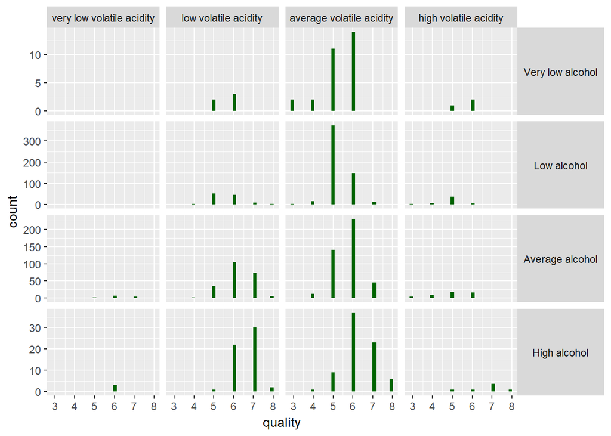

This plot gives me a general idea of data within different combinations of alcohol and volatile acidity. For example, there are no wines with very low volatile acidity and very low alcohol. I am interested in extreme cases. A wine with high alcohol content and low volatile acidity should be of good quality. We see on the graph that among these wines there are many 6 and 7 grades, a few 8 and 5. What differs wines in this category making them better or worse?

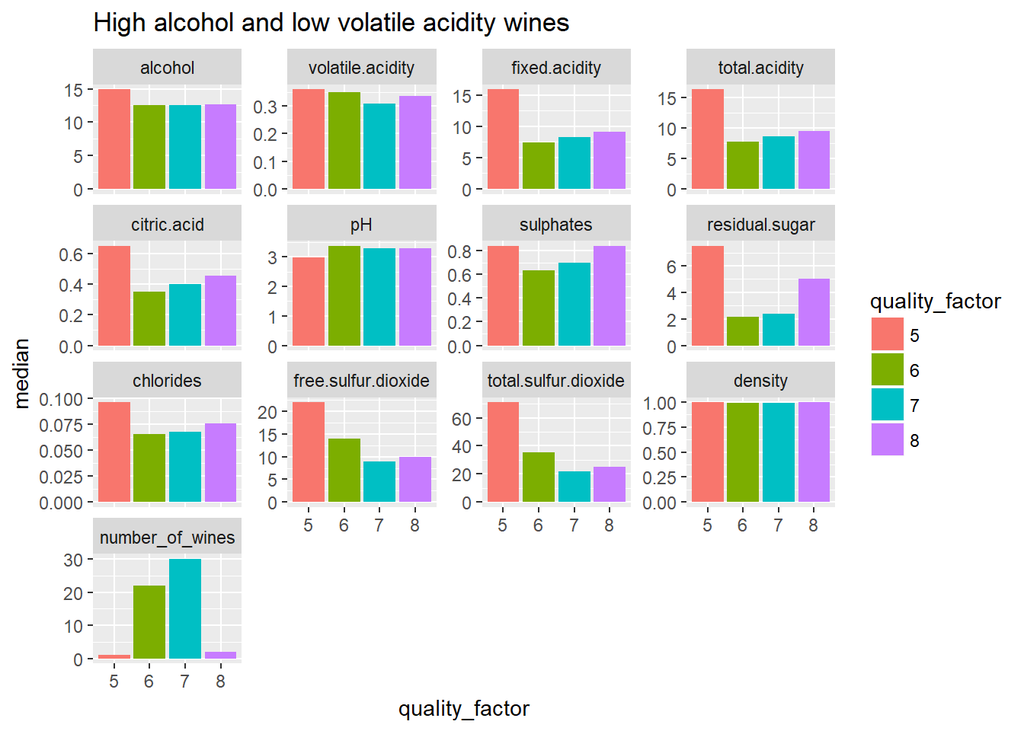

Here we see median values for each quality and each predictor variable. What might have contributed to the lowest grade of 5? Chlorides, total sulfur dioxide and residual sugar are are very high. In this case citric acid is very high and fixed acidity too.

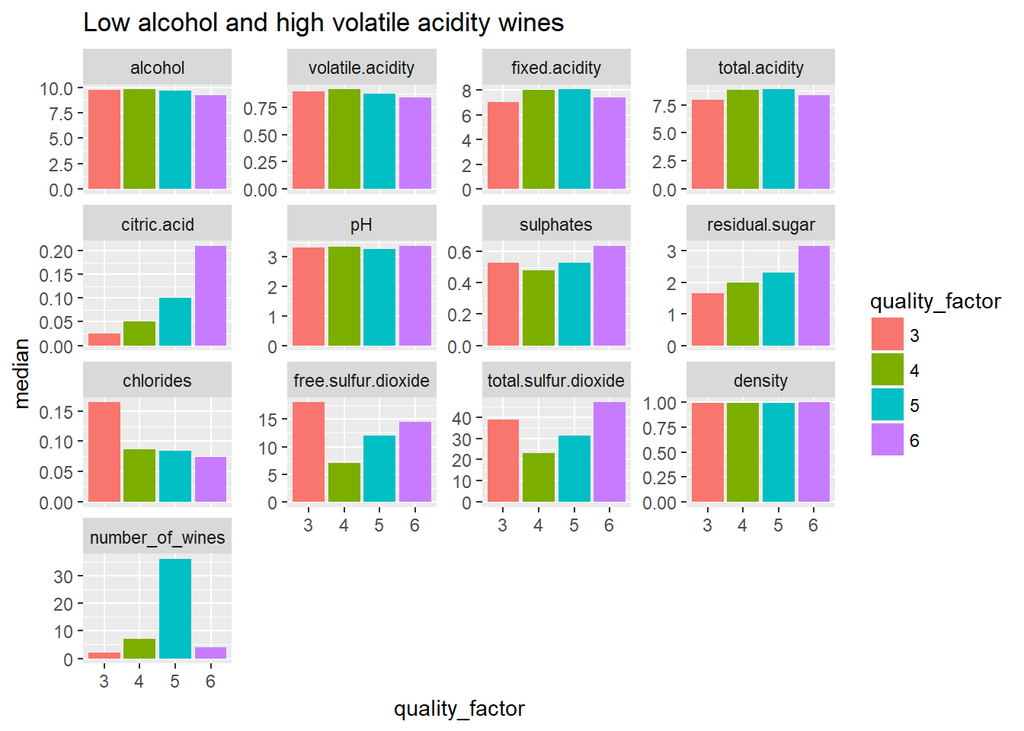

Here most of wines should be of lower quality, nevertheless, there is even a 6 grade wine. What differs them? Citric acid seems to have a clear increase. 6 grade wine has much more citric acid than other wines. Chlorides are decreasing. Residual sugar increases as grade increases.

It seems that depending on other parameters chlorides, residual sugar and total sulfur dioxide might influence positively or negatively the quality.

Let’s explore the relationship between residual sugar and fixed acidity

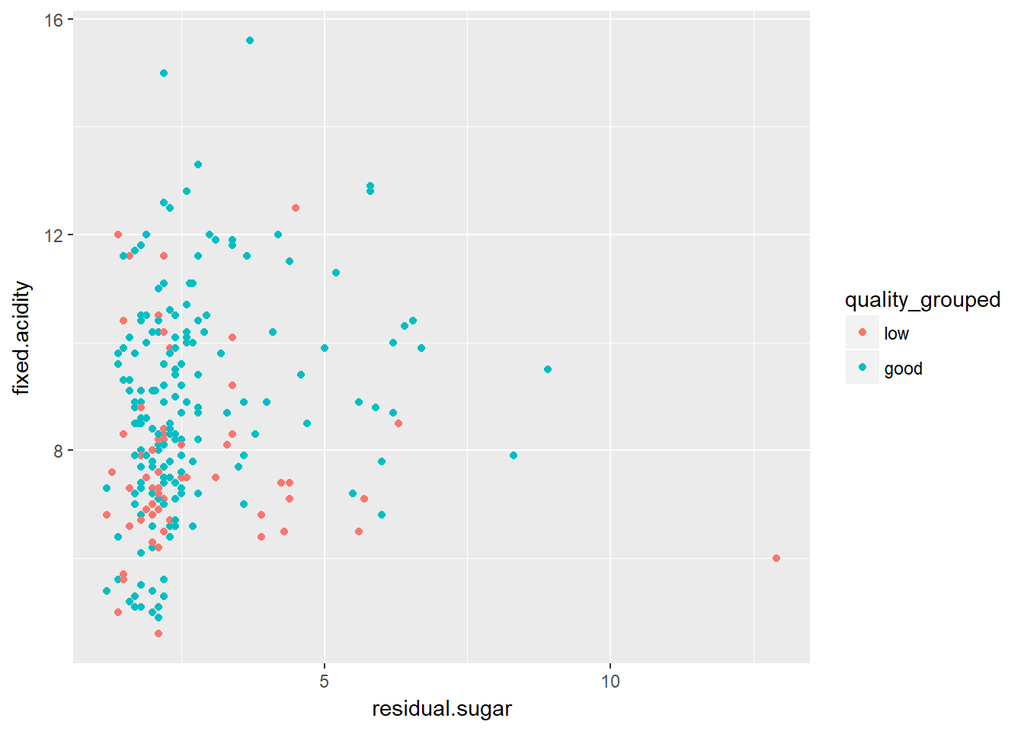

Here it seems that for higher sugar (> 3 g/l) poor wines tend to have lower fixed acidity.

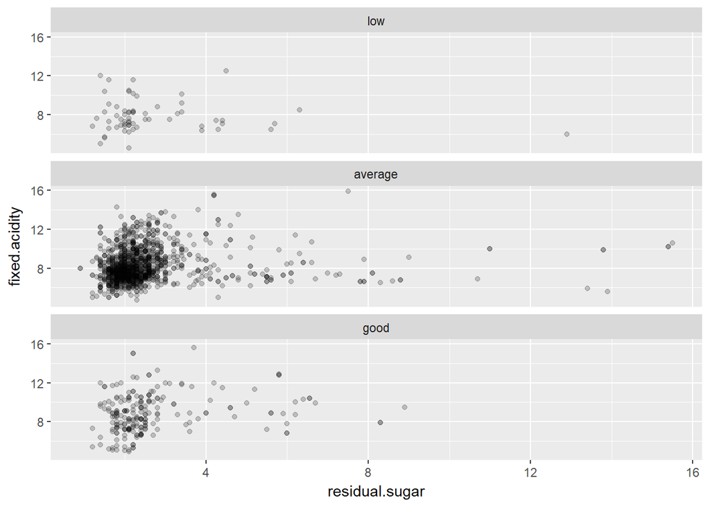

Despite my expectation I can not see a relationship between residual sugar and fixed acidity and its influence on quality. I notice though that average wines have more wines with high residual sugar than poor or good wines.

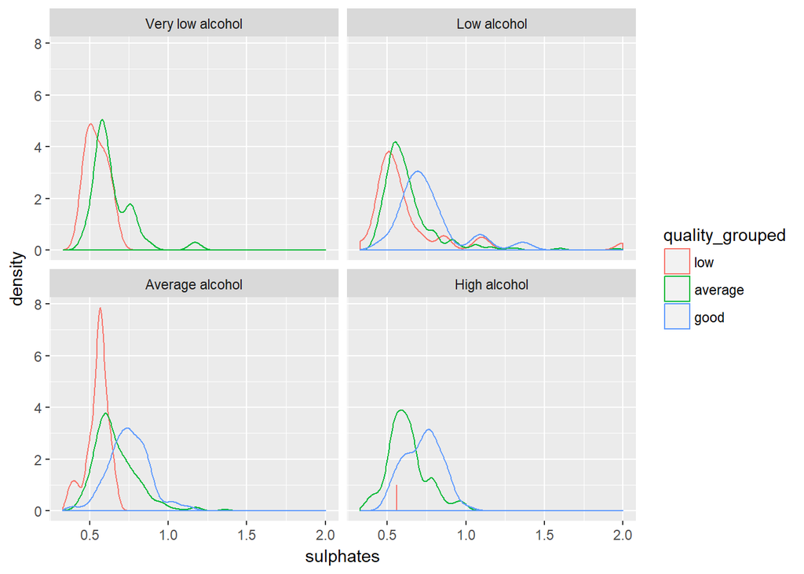

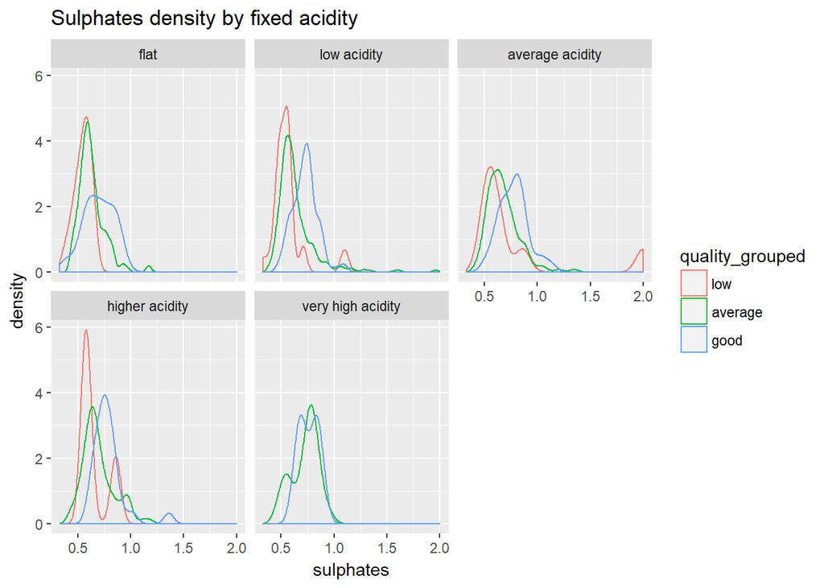

Same situation here: only for very high acidity wines sulphates content does not play a role.

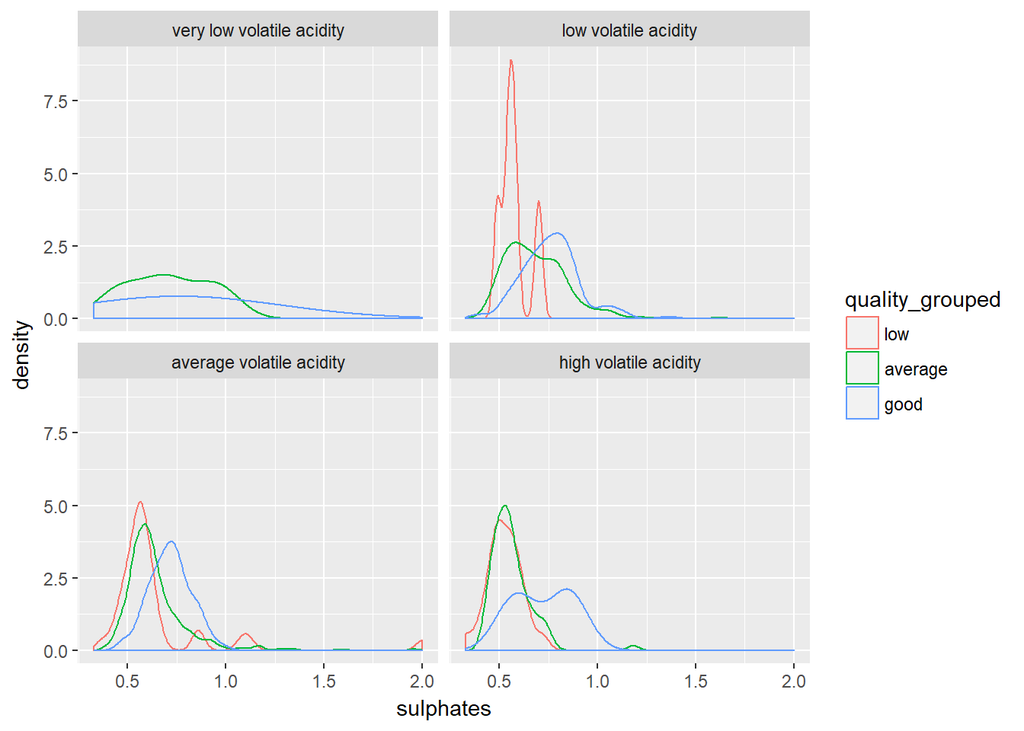

Here at very low volatile acidity the probability to get a good wine is much higher starting only at around 1.1 g/l of sulphates. At very low volatile acidity the sulphates content has to be higher to influence the quality.

For the next graph I created a new data frame with wines grouped by alcohol and quality and median values per predictor variable. Below are a few lines from this new data frame.

```
## # A tibble: 10 x 4
## # Groups:   alcohol_grouped [4]
##     alcohol_grouped quality_grouped   predictor median
##               <ord>           <ord>      <fctr>  <dbl>
##  1      Low alcohol             low citric.acid  0.195
##  2      Low alcohol         average citric.acid  0.220
##  3      Low alcohol            good citric.acid  0.400
##  4  Average alcohol             low citric.acid  0.055
##  5  Average alcohol         average citric.acid  0.270
##  6  Average alcohol            good citric.acid  0.410
##  7     High alcohol             low citric.acid  0.150
##  8     High alcohol         average citric.acid  0.260
##  9     High alcohol            good citric.acid  0.390
## 10 Very low alcohol             low   sulphates  0.535
```

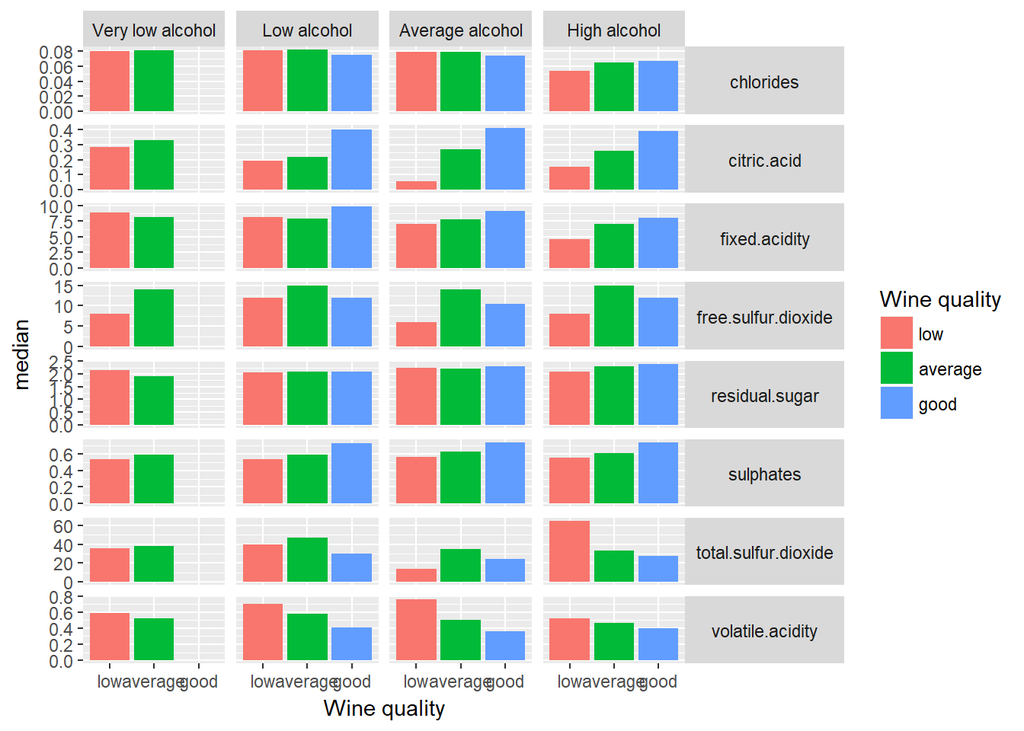

Here are median values for each predictor variable and wine quality. A wine quality gets better as: 1. Chlorides content increases for wines with high alcohol content and decreases slightly for other wines. Chlorides content is in general lower in wines with high alcohol content. 2. Citric acid and sulphates content increases 3. Fixed acidity increases, but is in general lower in wines with high alcohol content 4. Total sulfur dioxide decreases in wines with high alcohol content and is very high for poor wines with high alcohol content. Although, there is only one or two low quality wines with high alcohol, so it might be a coincidence.

Now I am ready to create my model.

I will take the following variables as predictors: alcohol, volatile acidity, fixed acidity, sulphates and totall sulphur dioxide

```
##
## Calls:
## m1: lm(formula = quality ~ alcohol + volatile.acidity, data = redwines)
## m2: lm(formula = quality ~ alcohol + volatile.acidity + fixed.acidity,
##     data = redwines)
## m3: lm(formula = quality ~ alcohol + volatile.acidity + sulphates,
##     data = redwines)
## m4: lm(formula = quality ~ alcohol + volatile.acidity + sulphates +
##     total.sulfur.dioxide, data = redwines)
##
## ================================================================================
##                              m1            m2            m3            m4
## --------------------------------------------------------------------------------
##   (Intercept)               3.095***      2.674***      2.611***      2.826***
##                            (0.184)       (0.218)       (0.196)       (0.201)
##   alcohol                   0.314***      0.321***      0.309***      0.295***
##                            (0.016)       (0.016)       (0.016)       (0.016)
##   volatile.acidity         -1.384***     -1.286***     -1.221***     -1.199***
##                            (0.095)       (0.099)       (0.097)       (0.097)
##   fixed.acidity                           0.036***
##                                          (0.010)
##   sulphates                                             0.679***      0.712***
##                                                        (0.101)       (0.101)
##   total.sulfur.dioxide                                               -0.002***
##                                                                      (0.001)
## --------------------------------------------------------------------------------
##   R-squared                 0.317         0.322         0.336         0.344
##   adj. R-squared            0.316         0.321         0.335         0.342
##   sigma                     0.668         0.665         0.659         0.655
##   F                       370.379       253.055       268.912       208.768
##   p                         0.000         0.000         0.000         0.000
##   Log-likelihood        -1621.814     -1615.379     -1599.384     -1589.835
##   Deviance                711.796       706.090       692.105       683.887
##   AIC                    3251.628      3240.758      3208.768      3191.669
##   BIC                    3273.136      3267.643      3235.654      3223.932
##   N                      1599          1599          1599          1599
## ================================================================================
```

# Multivariate Analysis

### Talk about some of the relationships you observed in this part of the investigation. Were there features that strengthened each other in terms of looking at your feature(s) of interest?

Fixed acidity strengthens alcohol effect on quality. This is particularly true for good and low quality wines, not for average wines. A wine with lower alcohol content needs higher fixed acidity to be of good quality. And vice versa: a wine with higher alcohol content can have a lower fixed acidity and still get a good grade.

### Were there any interesting or surprising interactions between features?

I noticed that some predictor variable influence quality only within certain groups of wines: for example, chlorides seem to positively influence quality only in high alcohol wines.

### OPTIONAL: Did you create any models with your dataset? Discuss the strengths and limitations of your model.

# Final Plots and Summary

### Plot One

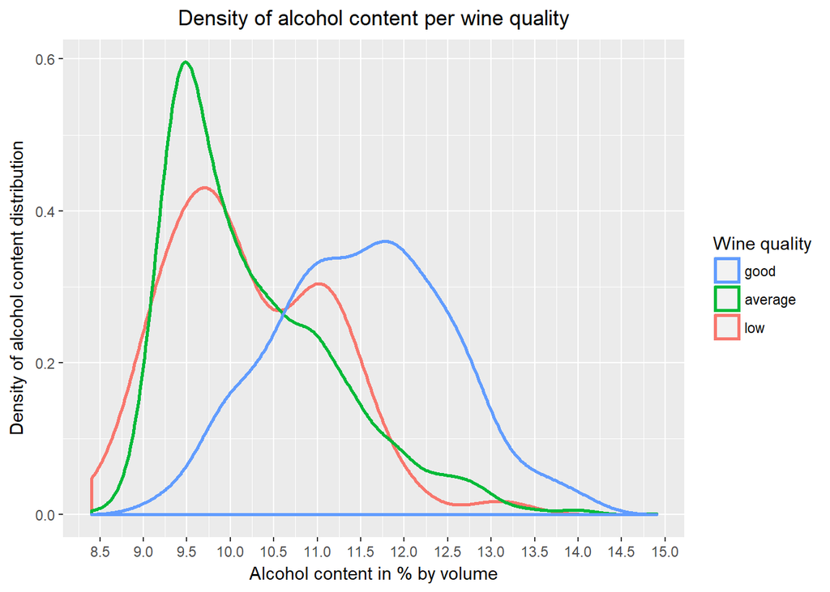

### Plot Two

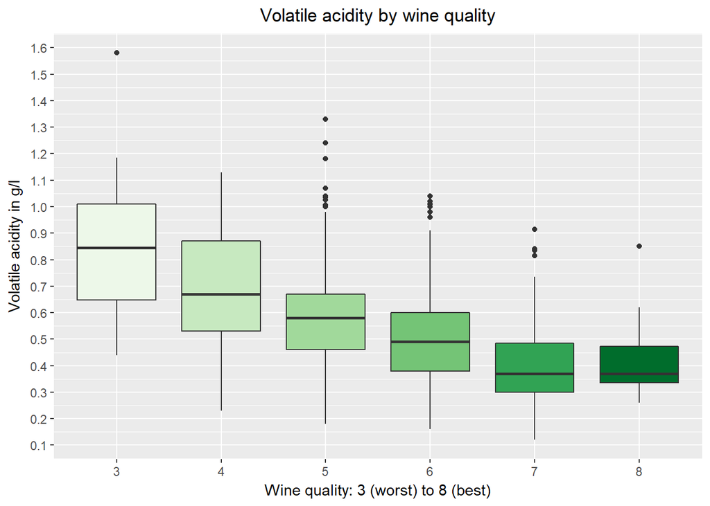

### Description Two

Median volatile acidity is decreasing as wine quality increases. Volatile acidity variance is the smallest for best quality wines (grade 8). Median volatile acidity of two best quality groups of wines (grade 7 and 8) is the same. Minimum volatile acidity of grade 8 wines is higher than minimum volatile acidity of grade 7 wines. This means that at some level of volatile acidity (around 0.20 - 0.25 g/l) further decrease in volatile acidity does not improve wine quality.

### Plot Three

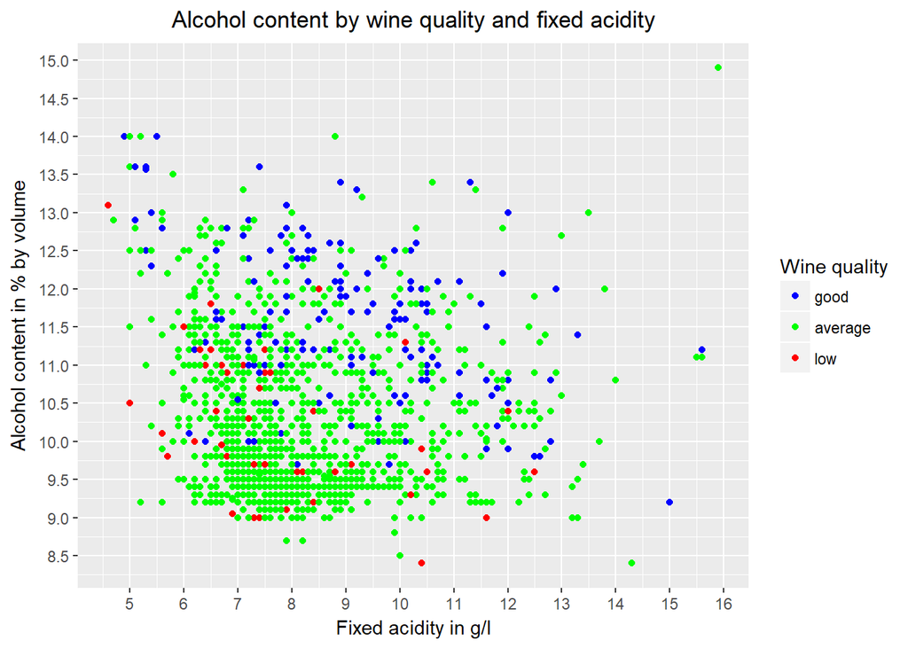

### Description Three

On this plot we see that good quality wines are mostly in the upper right part of the cluster, whereas low quality wines are mostly in the lower left part of the cluster. The higher the fixed acidity of a wine the lower minimum alcohol content is needed for the wine to be good. The lower the alcohol content the higher minimum fixed acidity is needed for a wine to be good. Fixed acidity reinforces the effect of alcohol content on quality.

# Reflection

In this project I explored the effect of several physicochemical properties of red wine on its quality. I used a sample of 1599 observations with 11 variables representing physicochemical properties of red wine. Here are my conclusions:

1. The strongest effect on quality is produced by alcohol content. The higher the alcohol content in a wine the higher the probability for this wine to be of a higher quality.
2. The second strongest effect is produced by volatile acidity. This time, the effect is negative. The higher the volatile acidity, the lower the probability for a wine to be of higher quality.
3. Fixed acidity reinforces the effect of alcohol on wine quality. This means that a wine with lower alcohol content but higher fixed acidity has chance to get the same grade as another wine with higher alcohol content and lower fixed acidity.
4. There is some slight positive relationship between sulphates and quality.
5. Citric acid affects wine quality, but as it is part of fixed acids and its effect is already taken into account when fixed acids are considered.
6. The effect of other variables can be different depending on the alcohol content. For example, chlorides play positive role only at high alcohol content.

**Challenges of this project**

The sample size is not big enough and also, the proportion of low and good quality wines is too small, so it is sometimes difficult to make conclusions with only a few wines as comparison.

Also, not all important wine ingredients were measured for this sample. For example, tannins or flavonoids.

**Surprises**

I was surprised to see that residual sugar does not have an effect on taste. I noticed though that at too high amounts residual sugar decreases wine quality. I also expected that acidity would have a stronger effect on quality.

**Future insights**

It would be interesting to look at a sample with equal amount of low, average and high quality wines. More detailed grades could be useful too: for example, grades with 0.5 scale. I would like to explore more the relationship between acidity and residual sugar or acidity and chlorides.